# Special symbols in ggplot2

x is not a subset of y

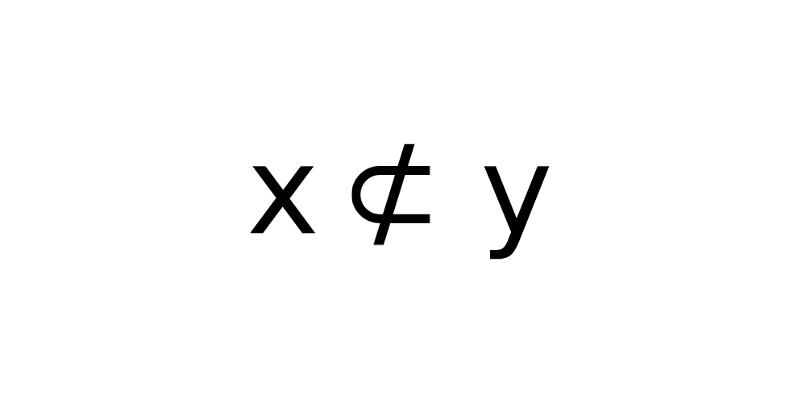

`x %supset% y`

x is a proper superset of y

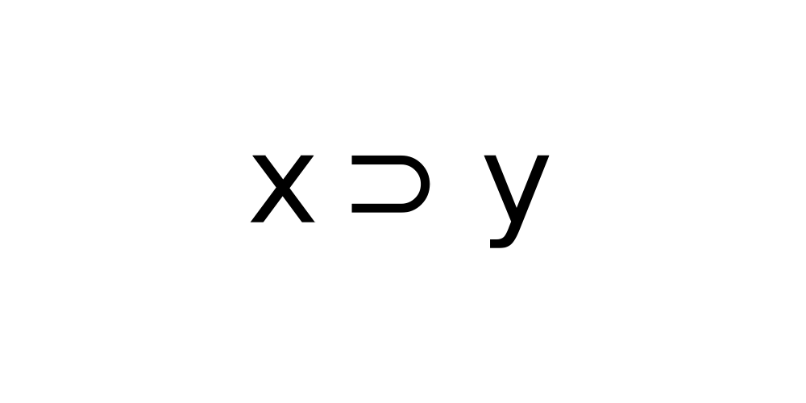

`x %supseteq% y`

x is a superset of y

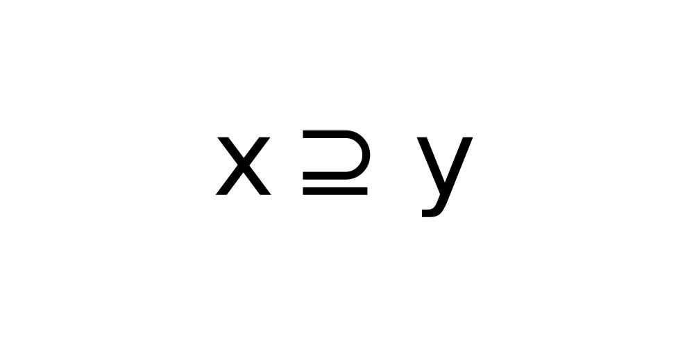

`x %in% y`

x is an element of y

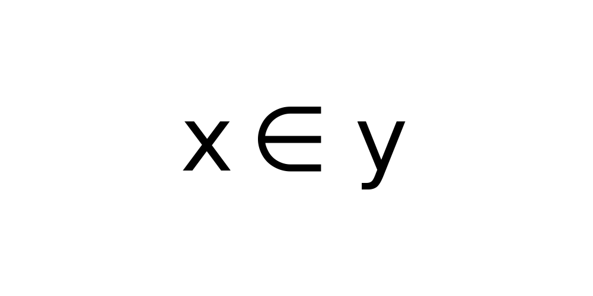

`x %notin% y`

x is not an element of y

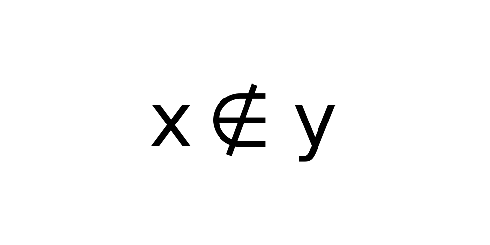

`hat(x)`

x with a circumflex

[figure not shown]

`tilde(x)`

x with a tilde

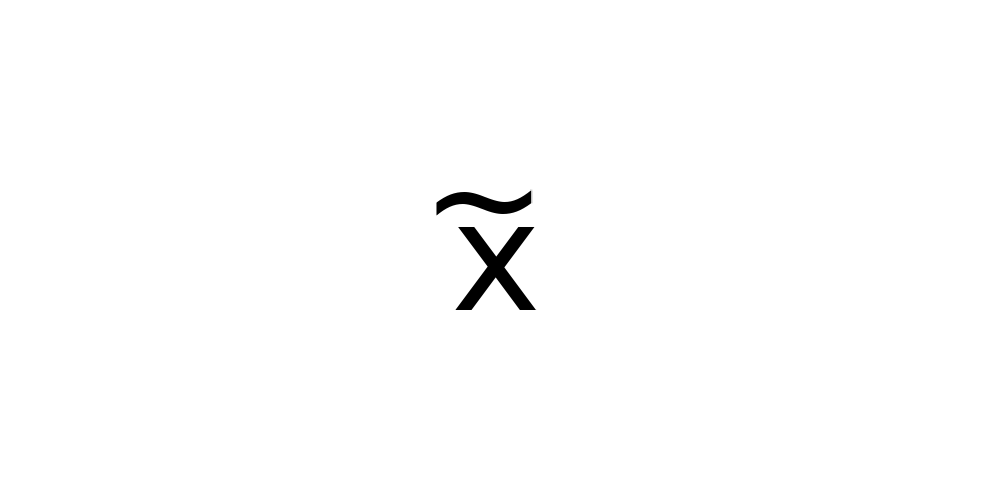

`dot(x)`

x with a dot

[figure not shown]

`ring(x)`

x with a ring

[figure not shown]

`bar(xy)`

xy with bar

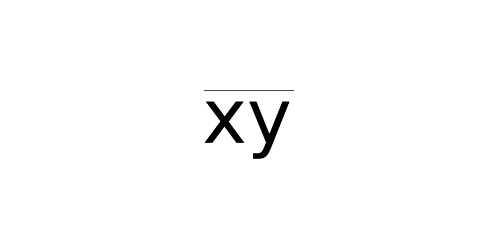

`widehat(xy)`

xy with a wide circumflex

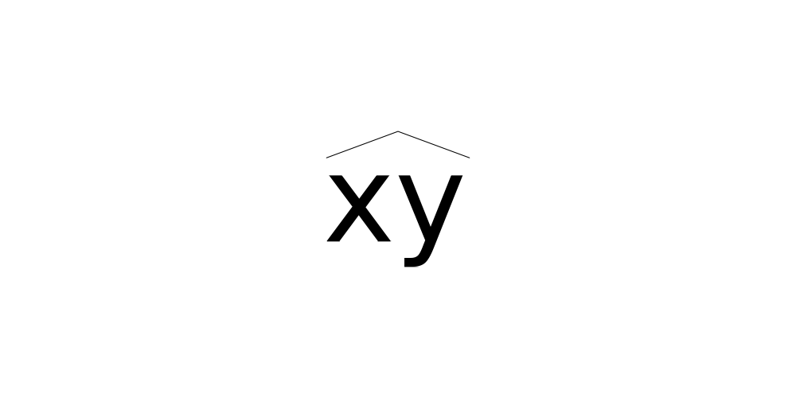

`widetilde(xy)`

xy with a wide tilde

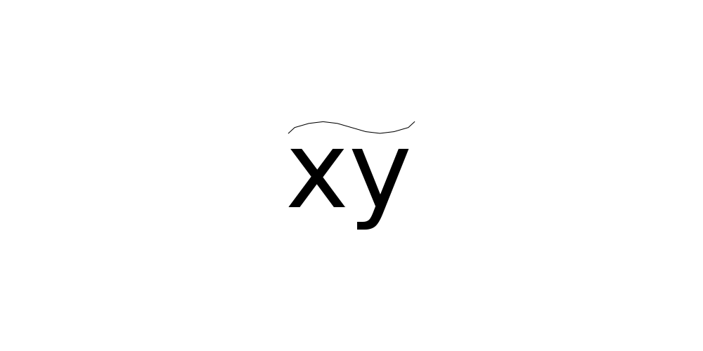

`x %<->% y`

x double-arrow y

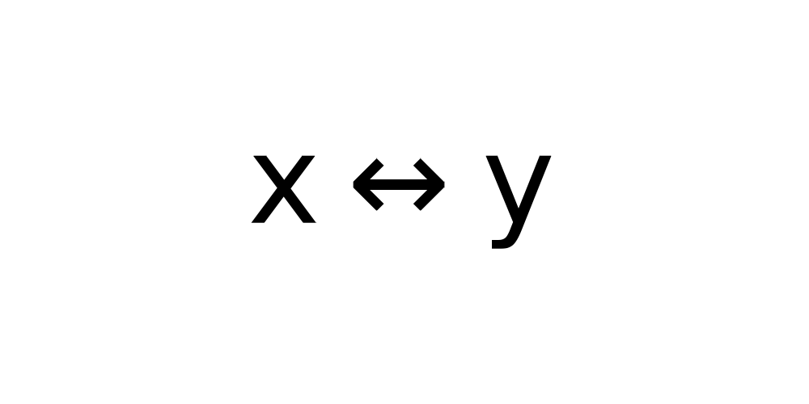

`x %->% y`

x right-arrow y

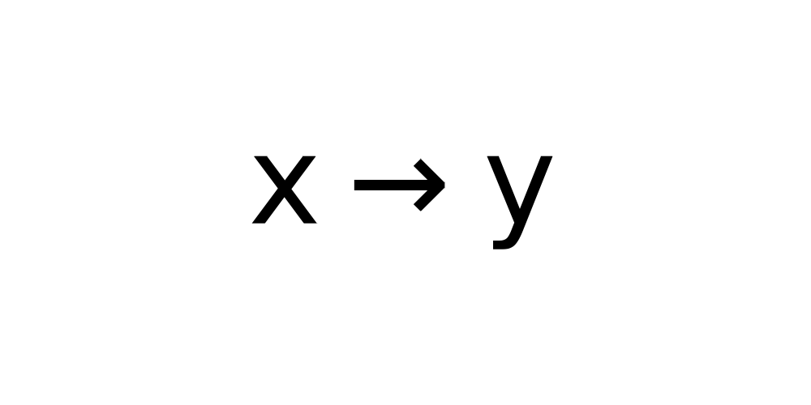

`x %<-% y`

x left-arrow y

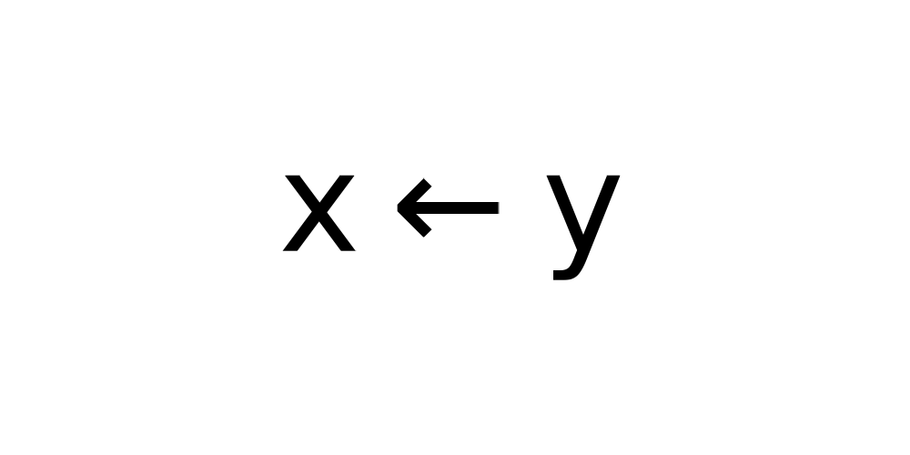

`x %up% y`

x up-arrow y

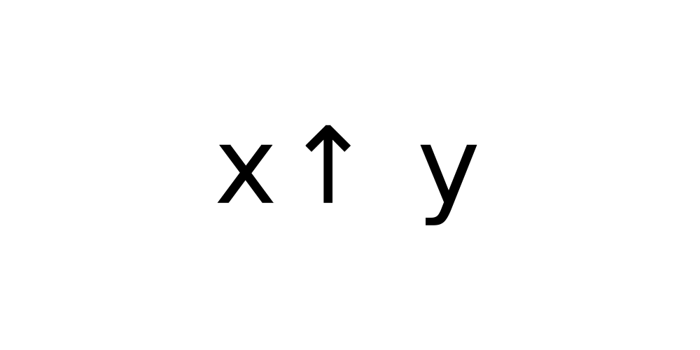

`x %down% y`

x down-arrow y

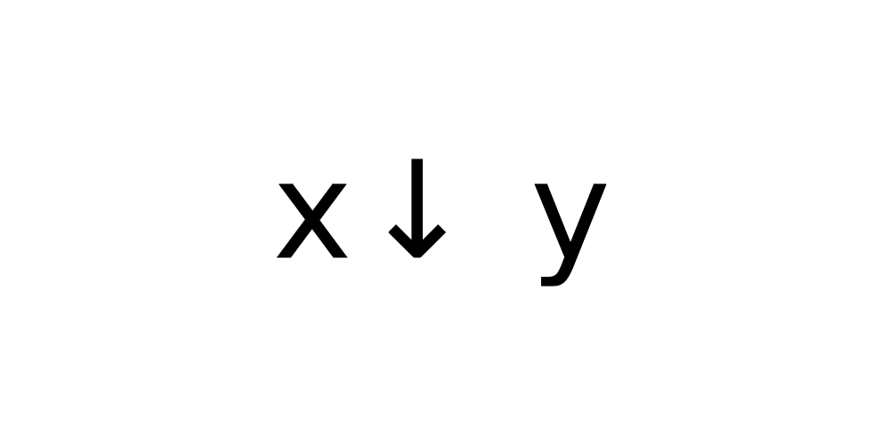

`x %<=>% y`

x is equivalent to y

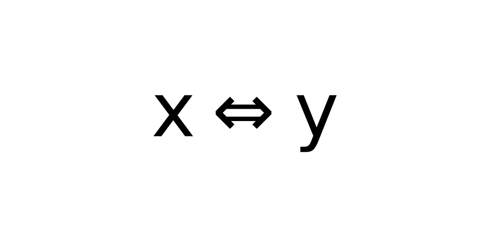

`x %=>% y`

x implies y

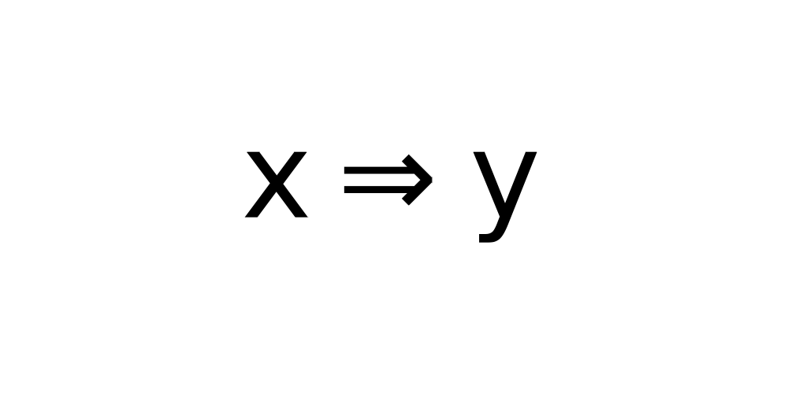

`x %<=% y`

y implies x

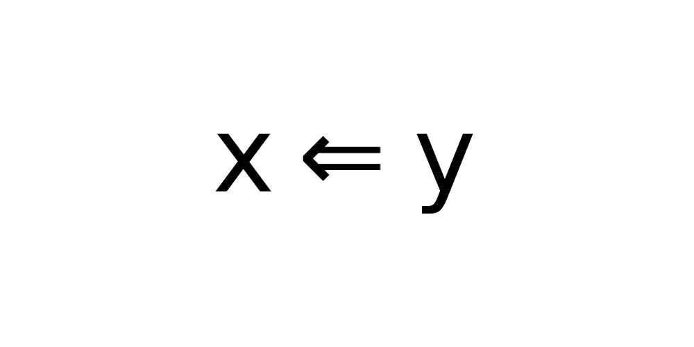

`x %dblup% y`

x double-up-arrow y

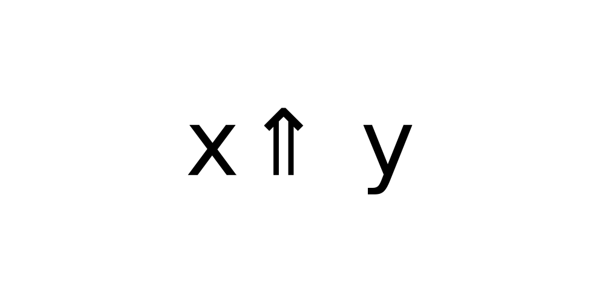

`x %dbldown% y`

x double-down-arrow y

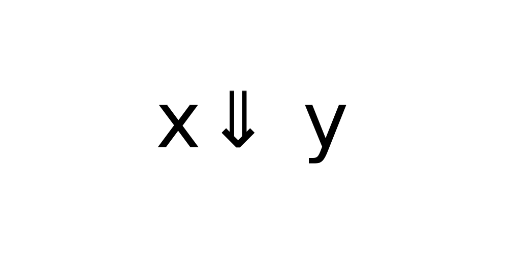

`alpha -- omega`

Greek symbols

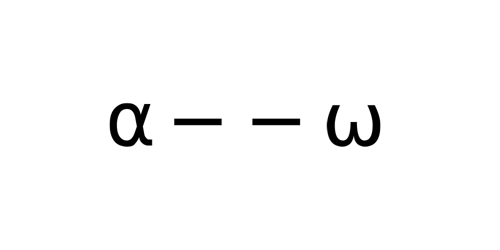

`Alpha -- Omega`

uppercase Greek symbols

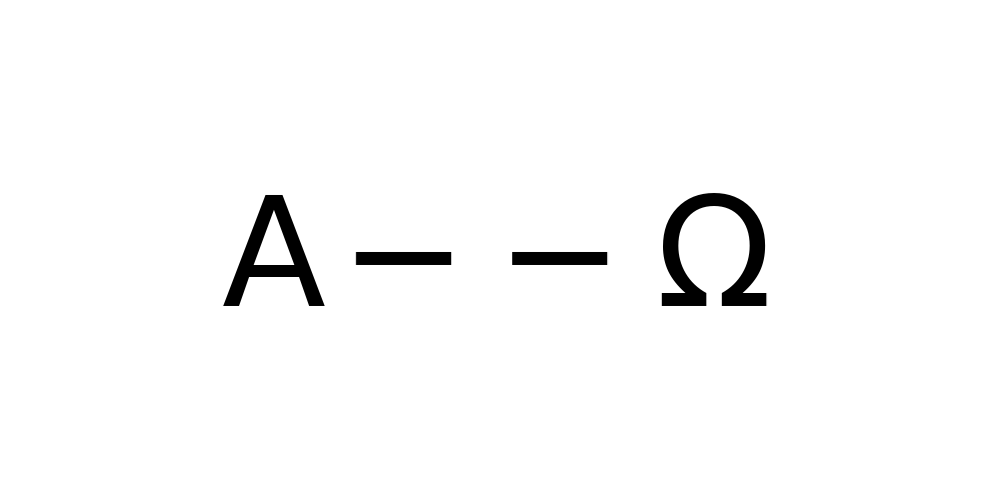

`theta1, phi1, sigma1, omega1`

cursive Greek symbols

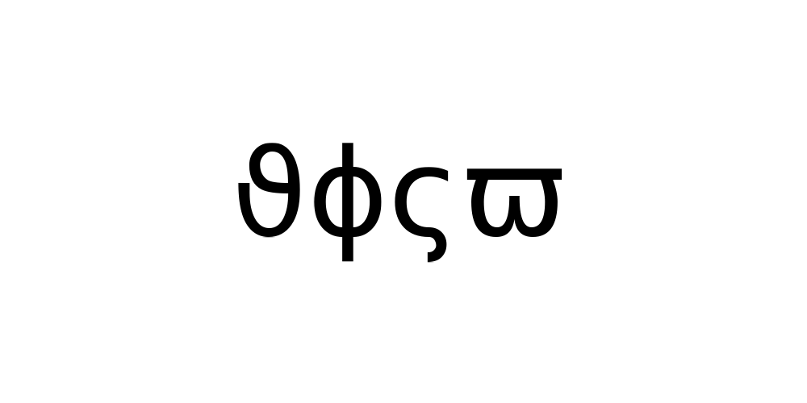

`Upsilon1`

capital upsilon with hook

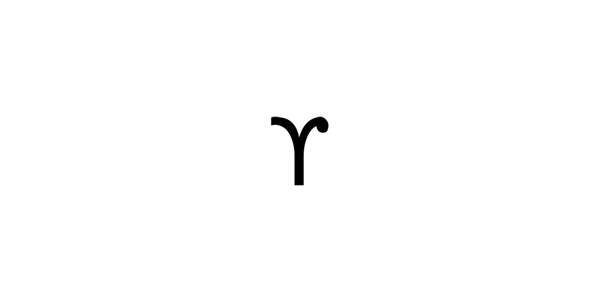

`aleph`

first letter of Hebrew alphabet

[figure not shown]

`infinity`

infinity symbol

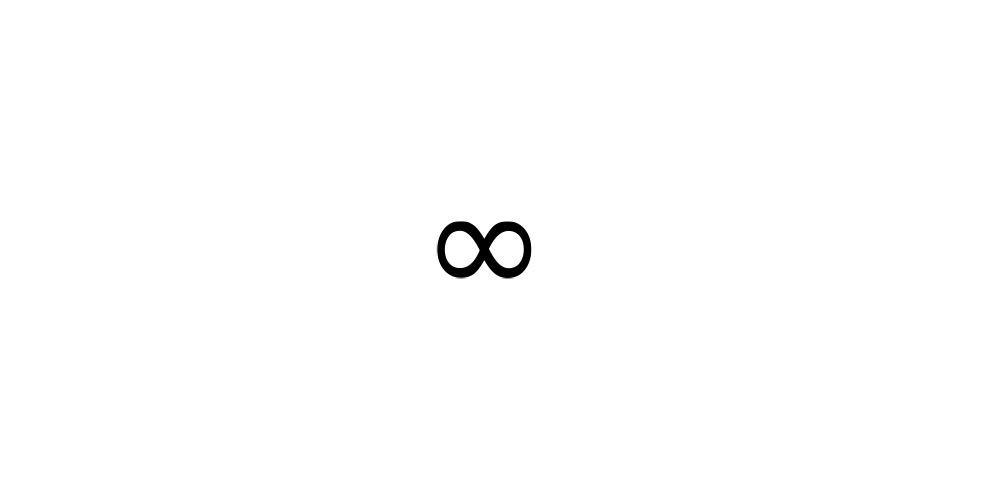

`partialdiff`

partial differential symbol

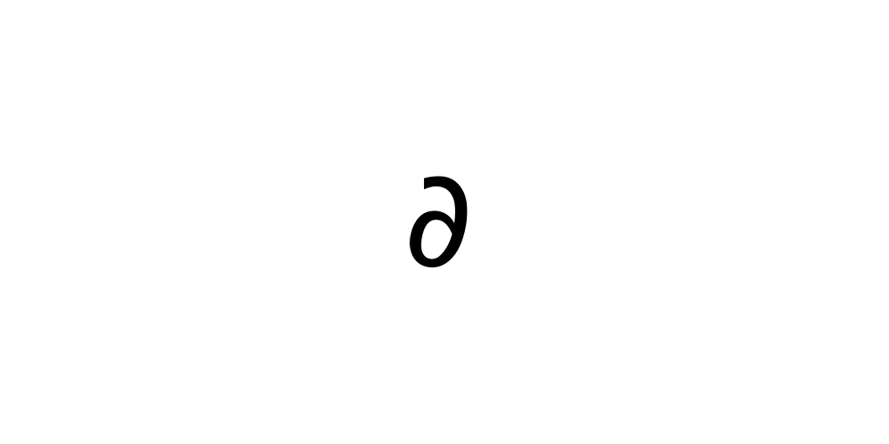

`nabla`

nabla, gradient symbol

[figure not shown]

`32*degree`

32 degrees

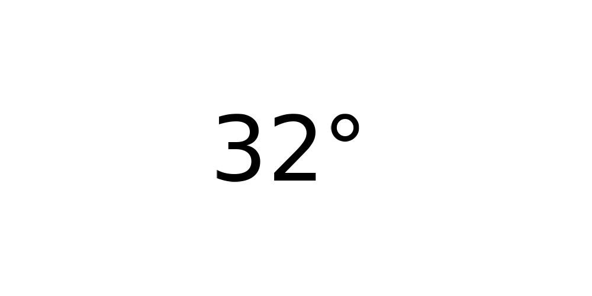

`60*minute`

60 minutes of angle

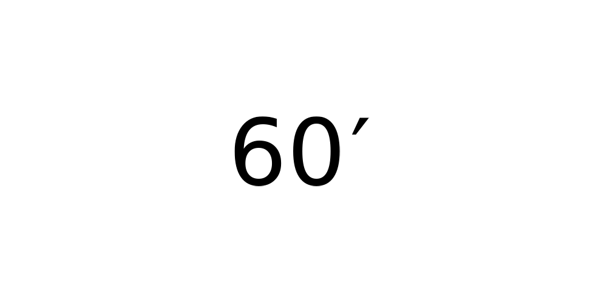

`30*second`

30 seconds of angle

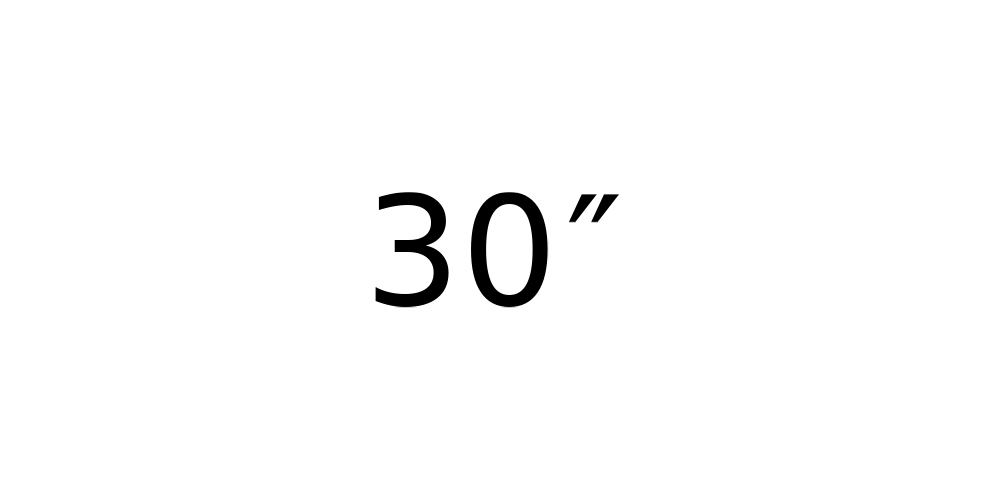

`scriptstyle(x)`

draw x in small size

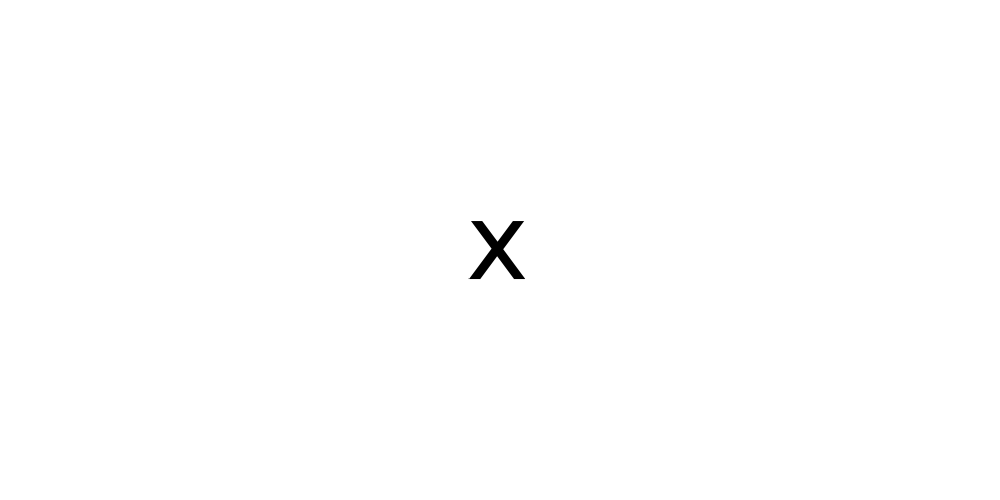

`scriptscriptstyle(x)`

draw x in very small size

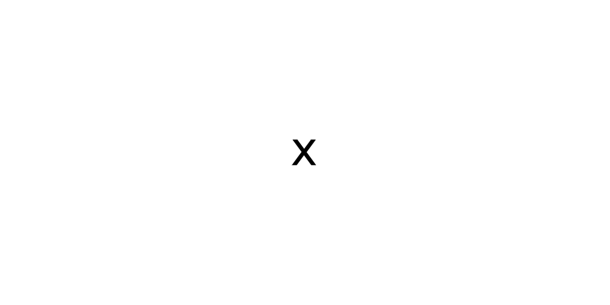

`underline(x)`

draw x underlined

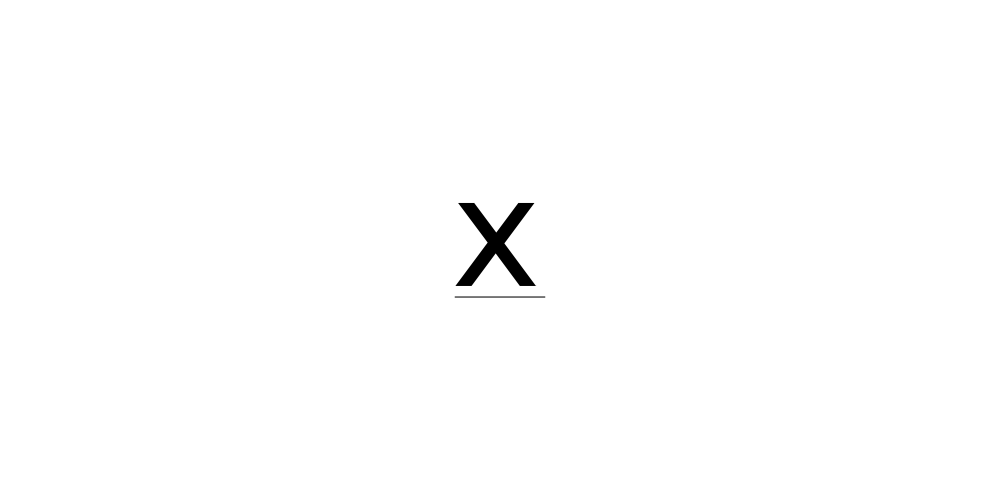

`x ~~ y`

put extra space between x and y

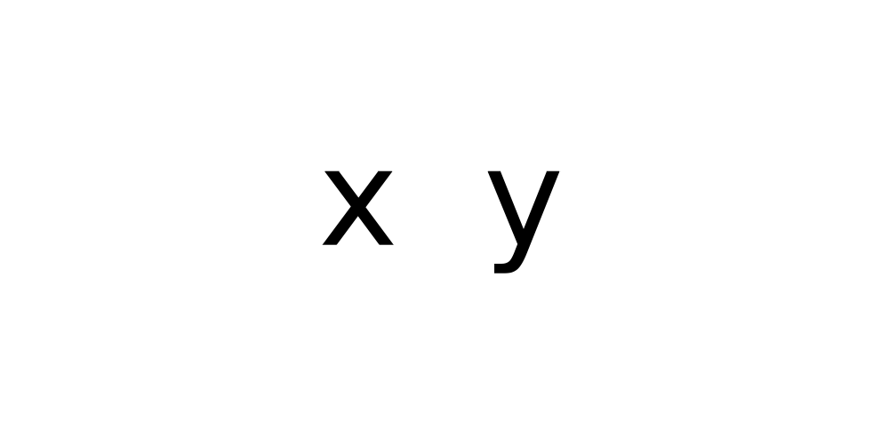

`x + phantom(0) + y`

leave gap for '0', but don't draw it

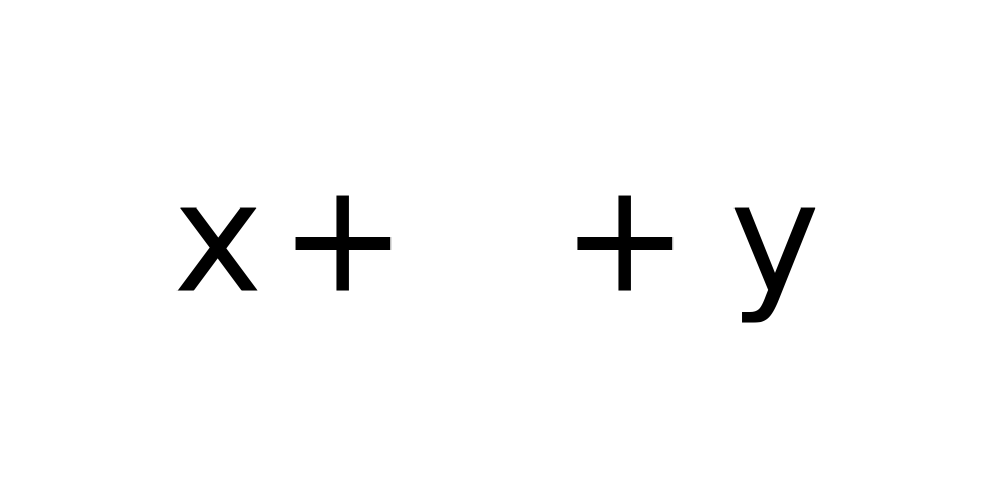

`x + over(1, phantom(0))`

leave vertical gap for '0' (don't draw)

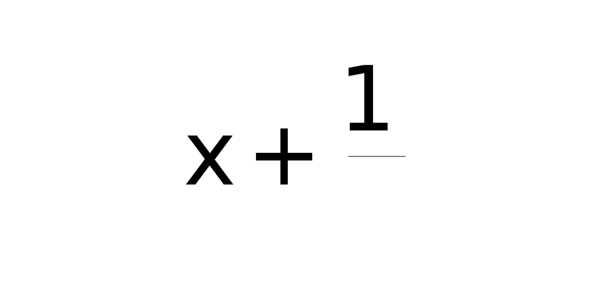

`frac(x, y)`

x over y

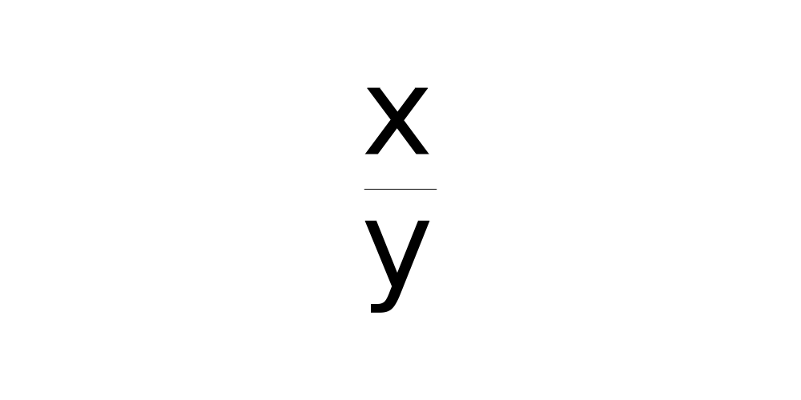

`over(x, y)`

x over y

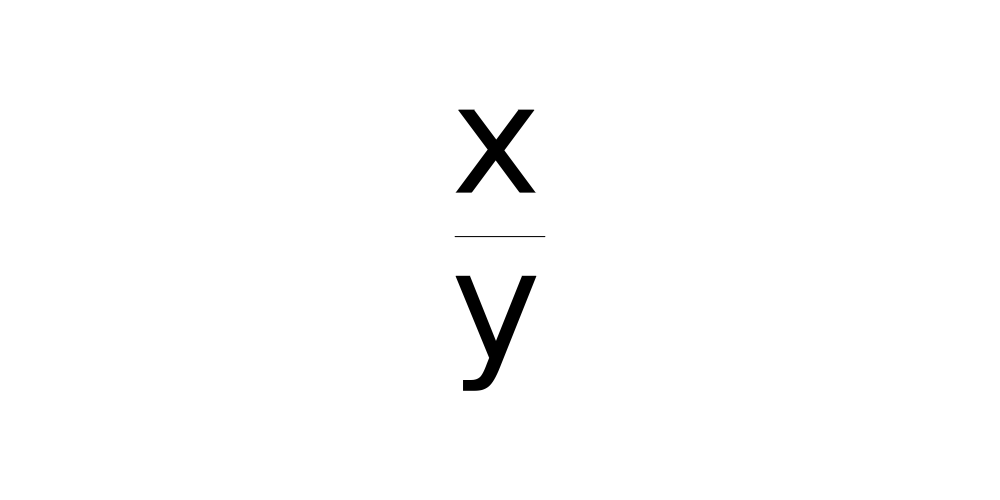

`atop(x, y)`

x over y (no horizontal bar)

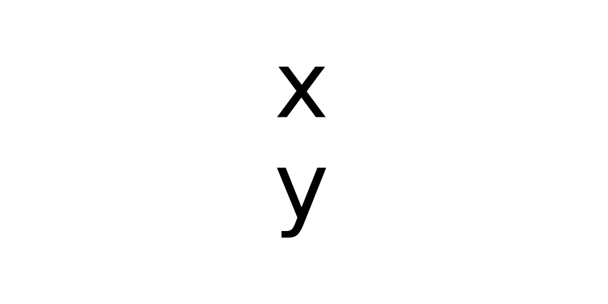

`sum(x[i], i==1, n)`

sum x[i] for i equals 1 to n

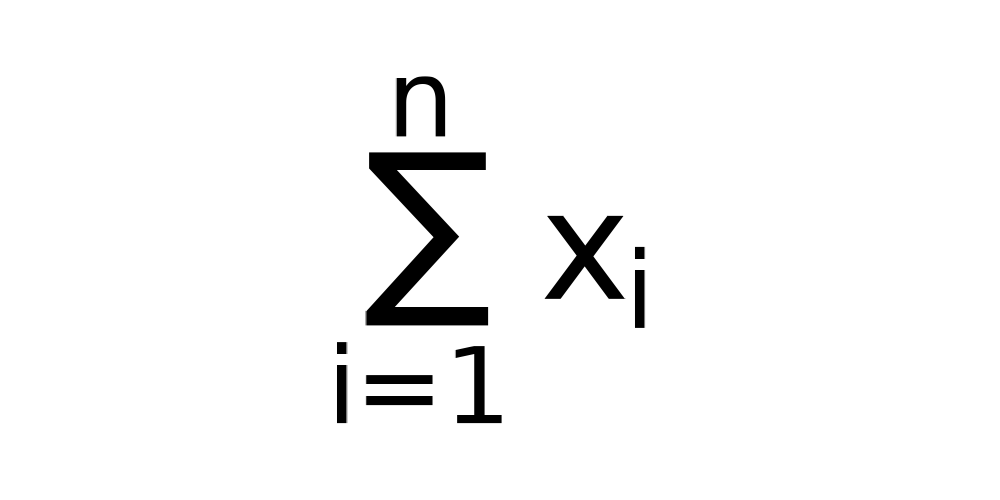

`prod(plain(P)(X==x), x)`

product of P(X=x) for all values of x

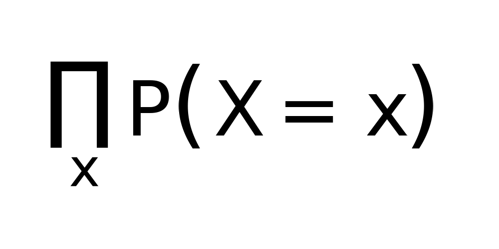

`integral(f(x)*dx, a, b)`

definite integral of f(x) wrt x

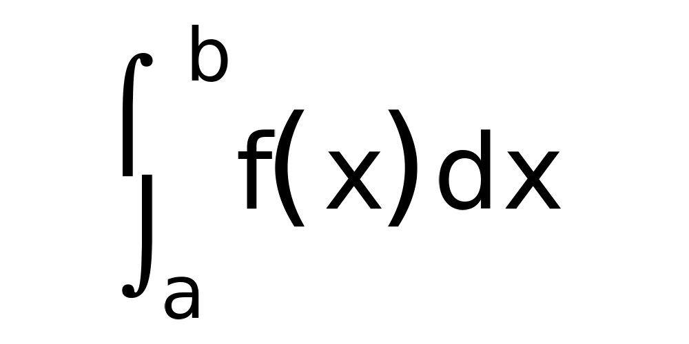

`union(A[i], i==1, n)`

union of A[i] for i equals 1 to n

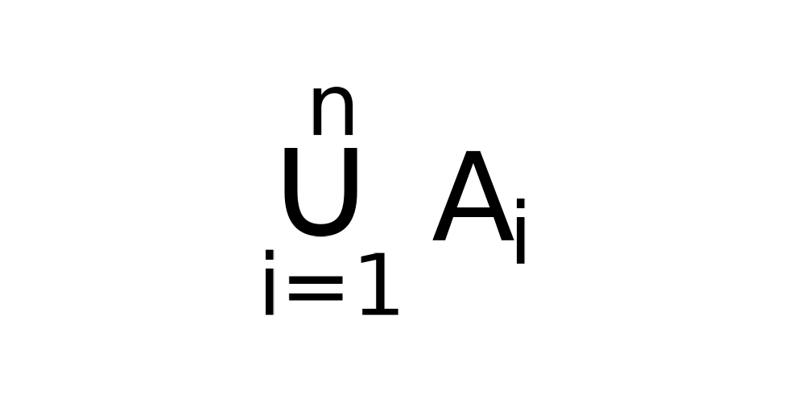

`intersect(A[i], i==1, n)`

intersection of A[i]

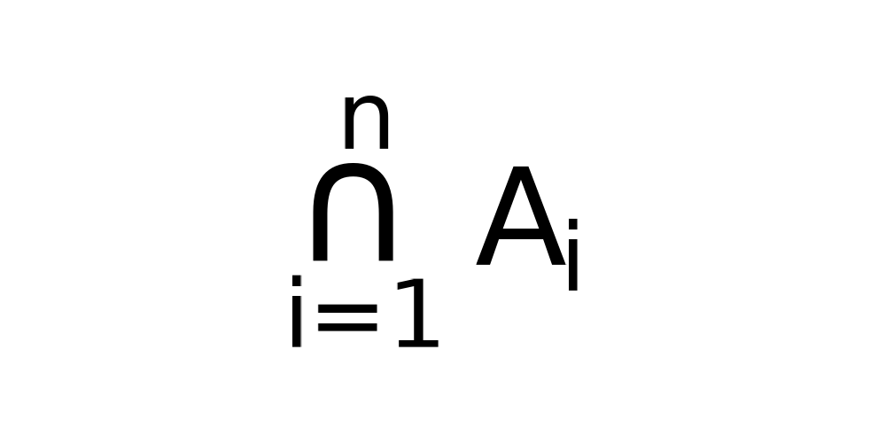

`lim(f(x), x %->% 0)`

limit of f(x) as x tends to 0

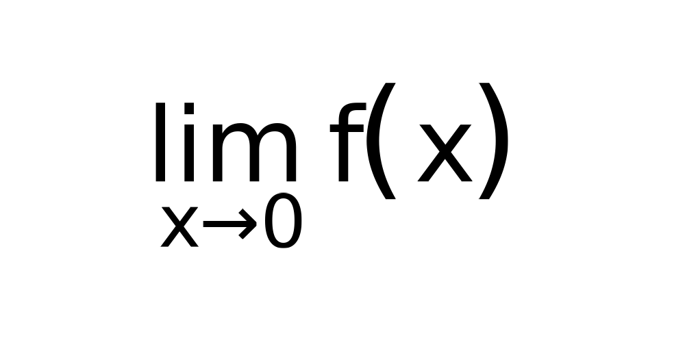

`min(g(x), x > 0)`

minimum of g(x) for x greater than 0

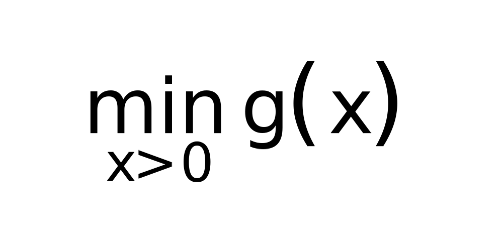

`inf(S)`

infimum of S

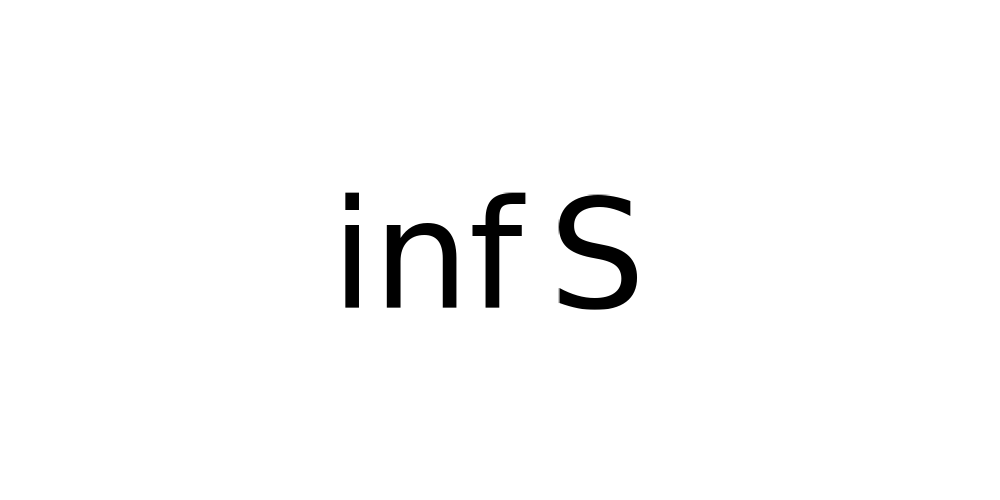

`sup(S)`

supremum of S

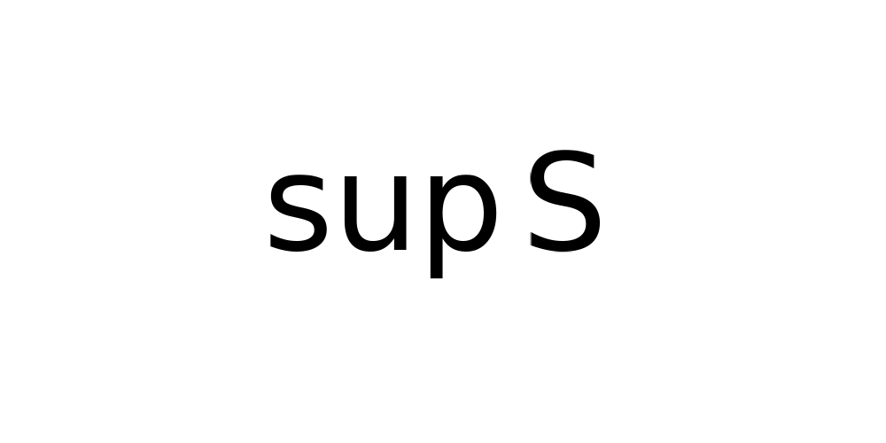

`x^y + z`

normal operator precedence

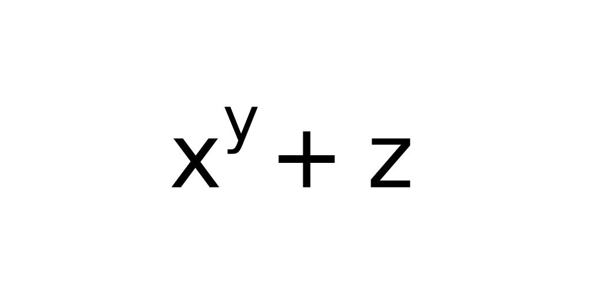

`x^(y + z)`

visible grouping of operands

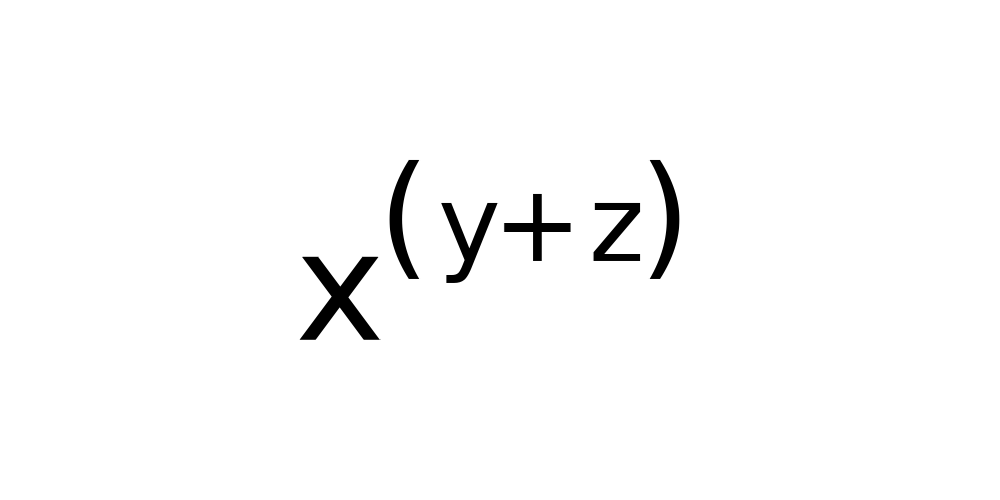

`x^{y + z}`

invisible grouping of operands

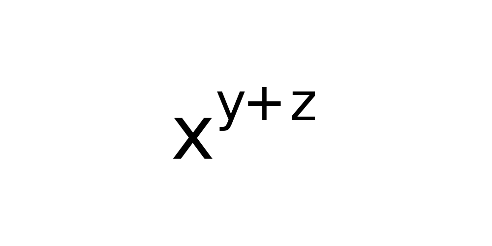

`group('(',list(a, b),']')`

specify left and right delimiters

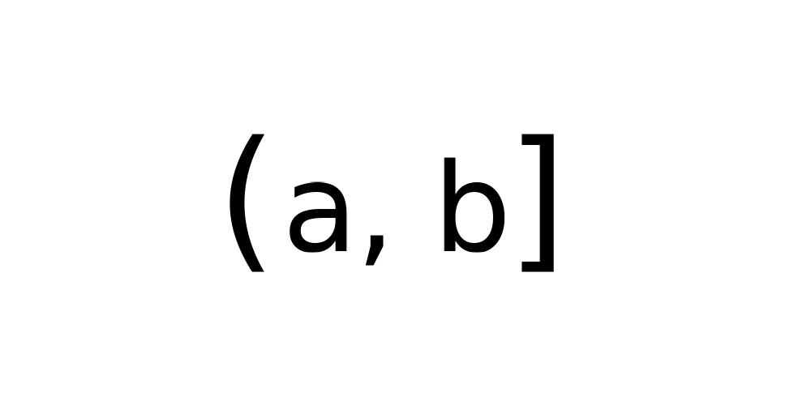

`bgroup('(',atop(x,y),')')`

use scalable delimiters

[figure not shown]

`group(lceil, x, rceil)`

special delimiters

[figure not shown]

`group(lfloor, x, rfloor)`

special delimiters

[figure not shown]

`group(langle, list(x, y), rangle)`

special delimiters

[figure not shown]

## Resources

- [`ggplot2::geom_text()`](https://ggplot2.tidyverse.org/reference/geom_text.html?q=text#ref-examples)
- [Stackoverflow question](https://stackoverflow.com/questions/47946232/ggplot2-annotation-with-text-sub-superscript-and-calculated-values)

## Footnotes

[^1]: You could also use straight text “R^2” without `deparse(bquote())` if you wanted to work with text.